# Evaluation of the performance cyber-attack detection models for various representations

Hidden for the time of the double-blind review process

2024-03-12

### The plan:

1. Loading all data.
2. Constructing ML-friendly representations of time windows from the model training and evaluation parts of data.
3. Conducting the initial experiments with ML models for predicting cyber attacks.

```r
# loading the preprocess data for the project
load(file = file.path("process_data_v2.RData"))

# loading data from the process discovery part
# this file contains: variant_dt, cluster_reps, largest_variants, extreme_variants
load(file = file.path("selected_variants.RData"))
head(variant_dt)
```

| compacted_trace | attack_prob | n_of_traces | cluster_id | distance_to_cluster_members |
| --- | --- | --- | --- | --- |
| www-data_mmap_yes,www-data_clone_yes,www-data_munmap_yes,multi_www-data_close_yes | 0.03267241 | 26322 | 1 | 40783.84348 |
| www-data_execve_yes,www-data_openat_yes,www-data_mmap_yes,www-data_close_yes,www-data_openat_yes,multi_www-data_mmap_yes,www-data_close_yes,www-data_munmap_yes,www-data_clone_yes,www-data_exit_group_N… | 0.03396399 | 27382 | 1 | 27817.22293 |
| www-data_execve_yes,www-data_openat_yes,www-data_mmap_yes,www-data_close_yes,www-data_openat_yes,multi_www-data_mmap_yes,www-data_close_yes,www-data_munmap_yes,www-data_openat_yes,multi_www-data_close… | 0.03403081 | 27387 | 1 | 24750.99297 |
| multi_root_close_openat_yes,root_openat_yes,multi_root_close_yes,root_openat_no,root_openat_yes,multi_root_close_openat_yes,root_openat_yes,multi_root_close_openat_yes,root_openat_yes,multi_root_close… | 0.01794692 | 1 | 2 | 91.59553 |
| root_exit_NA | 0.03481522 | 833 | 1 | 85827.00000 |
| root_socket_yes,root_close_yes | 0.03740586 | 2406 | 3 | 49609.18676 |

```r
# dealing with empty values in the SYSCALL_success column
process_discovery_data[SYSCALL_success == "", SYSCALL_success := "NA"]
model_training_data[SYSCALL_success == "", SYSCALL_success := "NA"]
test_data[SYSCALL_success == "", SYSCALL_success := "NA"]

# setting the table keys for efficiency
setkey(process_discovery_data, time_window_id, SYSCALL_timestamp)
setkey(model_training_data, time_window_id, SYSCALL_timestamp)
setkey(test_data, time_window_id, SYSCALL_timestamp)
```

### Constructing ML-friendly representations of time windows from the model training and evaluation parts of data:

```r
model_training_data[, time_window_id_SYSCALL_pid := paste0(time_window_id, "_", SYSCALL_pid)]
test_data[, time_window_id_SYSCALL_pid := paste0(time_window_id, "_", SYSCALL_pid)]

unique_action_ids <- model_training_data[, unique(paste(PROCESS_uid,
                                                        SYSCALL_syscall,
                                                        SYSCALL_success, sep = "_"))]
model_training_trace_dt <- model_training_data[, c(construct_process_trace(.SD),
                                                   attack = unique(is_attack)),
                                               by = time_window_id_SYSCALL_pid]

# The number of traces before compacting:
model_training_trace_dt[, uniqueN(trace)]
```

```
[1] 5765
```

```r
model_training_trace_dt <- compact_traces(model_training_trace_dt, unique_action_ids,
                                          show_progress = FALSE)
# The number of traces after compacting:
model_training_trace_dt[, uniqueN(compacted_trace)]
```

```
[1] 2096
```

```r
test_trace_dt <- test_data[, c(construct_process_trace(.SD),
                               attack = unique(is_attack)),
                           by = time_window_id_SYSCALL_pid]
# The number of traces in test data before compacting:
test_trace_dt[, uniqueN(trace)]
```

```
[1] 4119
```

```r
test_trace_dt <- compact_traces(test_trace_dt, unique_action_ids,
                                show_progress = FALSE)
# The number of traces in test data after compacting:
test_trace_dt[, uniqueN(compacted_trace)]
```

```
[1] 1453
```

```r
# The number of common traces between test and training data
sum(test_trace_dt[, unique(compacted_trace)] %chin% model_training_trace_dt[, unique(compacted_trace)])
```

```
[1] 673
```

```r
# The number of common traces between test and process discovery data
sum(test_trace_dt[, unique(compacted_trace)] %chin% variant_dt[, compacted_trace])
```

```
[1] 574
```

```r
# The number of common traces between training and process discovery data
sum(model_training_trace_dt[, unique(compacted_trace)] %chin% variant_dt[, compacted_trace])
```

```
[1] 869
```

### Setting hyperparameters of the prediction models

```r
model_training_trace_dt[, time_window_id := sapply(strsplit(time_window_id_SYSCALL_pid, "_"), first)]
test_trace_dt[, time_window_id := sapply(strsplit(time_window_id_SYSCALL_pid, "_"), first)]

tr_data_labels <- model_training_trace_dt[, .(is_attack = first(attack)), keyby = time_window_id]
prior_probs <- tr_data_labels[, .(prob = .N/nrow(tr_data_labels)), keyby = is_attack]

# hyperparameters for XGBoost:
n_trees <- 1000
params_xgb <- list(booster = "gbtree",
                  objective = "binary:logistic",
                  eta = 0.01,
                  max_depth = 8,
                  lambda = 1.0, alpha = 10.0,
                  subsample = 1.0, colsample_bytree = 0.8,
                  base_score = prior_probs[is_attack == TRUE, prob],
                  nthread = n_cores)

# hyperparameters for GLMnet:
params_glm = list(alpha = 0.9, nfolds = 10, nlambda = 200,
                  ws_glmnet = prior_probs[tr_data_labels, on = "is_attack"][, 1/prob])
```

### Constructing training and test sets using all variants present in the training data

```r
# representation by all compacted variants from the training data (no filtering)
unique_training_traces <- model_training_trace_dt[, unique(compacted_trace)]

training_dt <- model_training_trace_dt[, {selected_variants = (compacted_trace %chin% unique_training_traces);
                                          c(as.list(unique_training_traces %chin% compacted_trace),
                                           n_of_traces = .N,
                                           min_compacted_length = min(compacted_trace_length),
                                           mean_compacted_length = mean(compacted_trace_length),
                                           max_compacted_length = max(compacted_trace_length),
                                           min_length = min(trace_length),
                                           mean_length = mean(trace_length),
                                           max_length = max(trace_length),
                                           n_of_traces_selected = sum(selected_variants),
                                           min_compacted_length_selected = ifelse(any(selected_variants), min(compacted_trace_length[selected_variants]), 0L),
                                           mean_compacted_length_selected = ifelse(any(selected_variants), mean(compacted_trace_length[selected_variants]), 0),
                                           max_compacted_length_selected = ifelse(any(selected_variants), max(compacted_trace_length[selected_variants]), 0L),
                                           min_length_selected = ifelse(any(selected_variants), min(trace_length[selected_variants]), 0L),
                                           mean_length_selected = ifelse(any(selected_variants), mean(trace_length[selected_variants]), 0),
                                           max_length_selected = ifelse(any(selected_variants), max(trace_length[selected_variants]), 0L),
                                           tot_variant_length = sum(trace_length),
                                           tot_compacted_variant_length = sum(compacted_trace_length),
                                           tot_variant_length_selected = sum(trace_length[selected_variants]),
                                           tot_compacted_variant_length_selected = sum(compacted_trace_length[selected_variants]),
                                           is_attack = first(attack))},
                                       keyby = time_window_id]
setnames(training_dt,
         1:(length(unique_training_traces)+1),
         c("time_window_id", paste0("variant_", 1:length(unique_training_traces))))

test_dt <- test_trace_dt[, {selected_variants = (compacted_trace %chin% unique_training_traces);
                                          c(as.list(unique_training_traces %chin% compacted_trace),
                                           n_of_traces = .N,
                                           min_compacted_length = min(compacted_trace_length),
                                           mean_compacted_length = mean(compacted_trace_length),
                                           max_compacted_length = max(compacted_trace_length),
                                           min_length = min(trace_length),
                                           mean_length = mean(trace_length),
                                           max_length = max(trace_length),
                                           n_of_traces_selected = sum(selected_variants),
                                           min_compacted_length_selected = ifelse(any(selected_variants), min(compacted_trace_length[selected_variants]), 0L),
                                           mean_compacted_length_selected = ifelse(any(selected_variants), mean(compacted_trace_length[selected_variants]), 0),
                                           max_compacted_length_selected = ifelse(any(selected_variants), max(compacted_trace_length[selected_variants]), 0L),
                                           min_length_selected = ifelse(any(selected_variants), min(trace_length[selected_variants]), 0L),
                                           mean_length_selected = ifelse(any(selected_variants), mean(trace_length[selected_variants]), 0),
                                           max_length_selected = ifelse(any(selected_variants), max(trace_length[selected_variants]), 0L),
                                           tot_variant_length = sum(trace_length),
                                           tot_compacted_variant_length = sum(compacted_trace_length),
                                           tot_variant_length_selected = sum(trace_length[selected_variants]),
                                           tot_compacted_variant_length_selected = sum(compacted_trace_length[selected_variants]),
                                           is_attack = first(attack))},
                         keyby = time_window_id]

setnames(test_dt,
         1:(length(unique_training_traces)+1),
         c("time_window_id", paste0("variant_", 1:length(unique_training_traces))))
```

### Evaluation of the XGBoost model trained on the representation by all variants from the training data

```r
# building an XGBoost model for the representation by all compacted variants from the training data
xgboostModel <- construct_xgb_from_traces(training_dt, test_dt,
                                          n_trees = n_trees,
                                          params_xgb = params_xgb)
```

```
[1] 15.05  0.03 64.17
```

```r
# test score:
preds <- predict(xgboostModel, as.matrix(test_dt[, !c("time_window_id","is_attack")]))
print(colAUC(preds, test_dt[, is_attack]))
```

```
                    [,1]
FALSE vs. TRUE 0.9238131
```

```r
# confusion matrix
table(preds > training_dt[, mean(is_attack)], test_dt[, is_attack] > 0)
```

```
        FALSE TRUE
  FALSE  3992   25
  TRUE    849  151
```

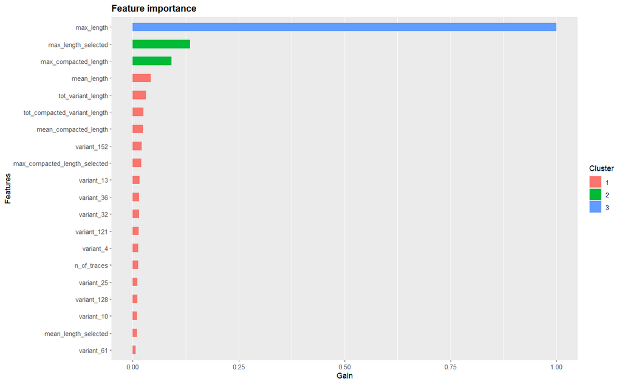

```r
# estimation of the feature importance
importance_matrix <- xgb.importance(colnames(training_dt[, !c("time_window_id","is_attack")]),
                                    model = xgboostModel)
feat_importance_plot = xgb.ggplot.importance(importance_matrix,
                                            measure = "Gain",
                                            rel_to_first = TRUE,
                                            top_n = 20)
feat_importance_plot + ylab("Gain")
```

```r
importance_matrix
```

| Feature | Gain | Cover | Frequency | Importance |
| --- | --- | --- | --- | --- |
| max_length | 6.260422e-01 | 2.153455e-01 | 1.326678e-01 | 6.260422e-01 |
| max_length_selected | 8.433846e-02 | 4.006279e-02 | 2.430556e-02 | 8.433846e-02 |
| max_compacted_length | 5.720490e-02 | 2.502000e-02 | 2.973090e-02 | 5.720490e-02 |
| mean_length | 2.639261e-02 | 6.132046e-02 | 8.608218e-02 | 2.639261e-02 |
| tot_variant_length | 1.933832e-02 | 5.245164e-02 | 5.975116e-02 | 1.933832e-02 |
| tot_compacted_variant_length | 1.569809e-02 | 3.053521e-02 | 5.468750e-02 | 1.569809e-02 |
| mean_compacted_length | 1.514588e-02 | 6.623317e-02 | 8.557581e-02 | 1.514588e-02 |
| variant_152 | 1.299486e-02 | 3.944029e-02 | 2.994792e-02 | 1.299486e-02 |
| max_compacted_length_selected | 1.262730e-02 | 4.296769e-03 | 4.629630e-03 | 1.262730e-02 |
| variant_13 | 1.020872e-02 | 2.258729e-02 | 2.228009e-02 | 1.020872e-02 |

[output cut: 67 more lines]

```r
# building model GLMnet model for the representation by all compacted variants from the training data
glmnetModel <- construct_glm_from_traces(training_dt, test_dt,
                                         params_glm = params_glm)
```

```
[1]  961.98    4.19 2159.72
```

```r
# test score:
preds <- glmnetModel$te_preds
print(colAUC(preds, test_dt[, is_attack]))
```

```
                      s1
FALSE vs. TRUE 0.6311102
```

```r
# confusion matrix
table(preds > 0.5, test_dt[, is_attack] > 0)
```

```
        FALSE TRUE
  FALSE  3683   66
  TRUE   1158  110
```

```r
# estimation of the feature importance
coefs <- coef(glmnetModel$model, s = "lambda.min")
sum(coefs != 0)
```

[output not shown]

```r
mean(coefs != 0)
```

```
[1] 0.870922
```

```r
save(training_dt, test_dt, glmnetModel, xgboostModel, params_glm, params_xgb,
     file = "data_and_models_xgb_glm_all_training_variants.RData")
```

### Constructing training and test sets using all variants discovered in the process discovery part of data

```r
training_dt <- model_training_trace_dt[, {selected_variants = (compacted_trace %chin% variant_dt[, compacted_trace]);
                                          c(as.list(variant_dt[, compacted_trace] %chin% compacted_trace),
                                           n_of_traces = .N,
                                           min_compacted_length = min(compacted_trace_length),
                                           mean_compacted_length = mean(compacted_trace_length),
                                           max_compacted_length = max(compacted_trace_length),
                                           min_length = min(trace_length),
                                           mean_length = mean(trace_length),
                                           max_length = max(trace_length),
                                           n_of_traces_selected = sum(selected_variants),
                                           min_compacted_length_selected = ifelse(any(selected_variants), min(compacted_trace_length[selected_variants]), 0L),
                                           mean_compacted_length_selected = ifelse(any(selected_variants), mean(compacted_trace_length[selected_variants]), 0),
                                           max_compacted_length_selected = ifelse(any(selected_variants), max(compacted_trace_length[selected_variants]), 0L),
                                           min_length_selected = ifelse(any(selected_variants), min(trace_length[selected_variants]), 0L),
                                           mean_length_selected = ifelse(any(selected_variants), mean(trace_length[selected_variants]), 0),
                                           max_length_selected = ifelse(any(selected_variants), max(trace_length[selected_variants]), 0L),
                                           tot_variant_length = sum(trace_length),
                                           tot_compacted_variant_length = sum(compacted_trace_length),
                                           tot_variant_length_selected = sum(trace_length[selected_variants]),
                                           tot_compacted_variant_length_selected = sum(compacted_trace_length[selected_variants]),
                                           is_attack = first(attack))},
                                       keyby = time_window_id]
setnames(training_dt,
         1:(nrow(variant_dt)+1),
         c("time_window_id", paste0("trace_", 1:nrow(variant_dt))))

test_dt <- test_trace_dt[, {selected_variants = (compacted_trace %chin% variant_dt[, compacted_trace]);
                                          c(as.list(variant_dt[, compacted_trace] %chin% compacted_trace),
                                           n_of_traces = .N,
                                           min_compacted_length = min(compacted_trace_length),
                                           mean_compacted_length = mean(compacted_trace_length),
                                           max_compacted_length = max(compacted_trace_length),
                                           min_length = min(trace_length),
                                           mean_length = mean(trace_length),
                                           max_length = max(trace_length),
                                           n_of_traces_selected = sum(selected_variants),
                                           min_compacted_length_selected = ifelse(any(selected_variants), min(compacted_trace_length[selected_variants]), 0L),
                                           mean_compacted_length_selected = ifelse(any(selected_variants), mean(compacted_trace_length[selected_variants]), 0),
                                           max_compacted_length_selected = ifelse(any(selected_variants), max(compacted_trace_length[selected_variants]), 0L),
                                           min_length_selected = ifelse(any(selected_variants), min(trace_length[selected_variants]), 0L),
                                           mean_length_selected = ifelse(any(selected_variants), mean(trace_length[selected_variants]), 0),
                                           max_length_selected = ifelse(any(selected_variants), max(trace_length[selected_variants]), 0L),
                                           tot_variant_length = sum(trace_length),
                                           tot_compacted_variant_length = sum(compacted_trace_length),
                                           tot_variant_length_selected = sum(trace_length[selected_variants]),
                                           tot_compacted_variant_length_selected = sum(compacted_trace_length[selected_variants]),
                                           is_attack = first(attack))},
                         keyby = time_window_id]
setnames(test_dt,
         1:(nrow(variant_dt)+1),
         c("time_window_id", paste0("trace_", 1:nrow(variant_dt))))
```

### Evaluation of the XGBoost model trained on the representation only by variants discovered in the process discovery part of data

```r
# building model
xgboostModel <- construct_xgb_from_traces(training_dt, test_dt,
                                          n_trees = n_trees,
                                          params_xgb = params_xgb)
```

```
[1]  8.41  0.10 44.64
```

```r
# test score:
preds <- predict(xgboostModel, as.matrix(test_dt[, !c("time_window_id","is_attack")]))
print(colAUC(preds, test_dt[, is_attack]))
```

```
                    [,1]
FALSE vs. TRUE 0.9259398
```

```r
# confusion matrix
table(preds > training_dt[, mean(is_attack)], test_dt[, is_attack] > 0)
```

```
        FALSE TRUE
  FALSE  4067   25
  TRUE    774  151
```

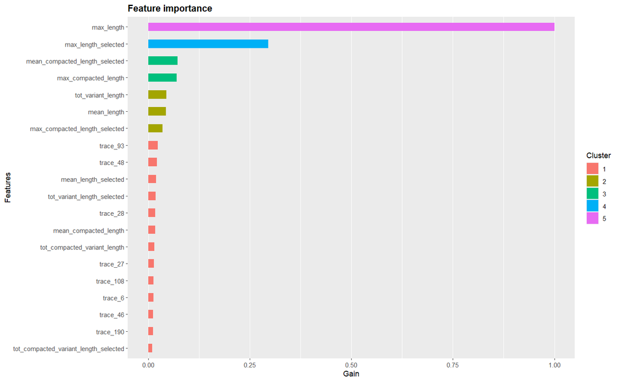

```r
# estimation of the feature importance
importance_matrix <- xgb.importance(colnames(training_dt[, !c("time_window_id","is_attack")]),
                                    model = xgboostModel)
feat_importance_plot = xgb.ggplot.importance(importance_matrix,
                                            measure = "Gain",
                                            rel_to_first = TRUE,
                                            top_n = 20)
feat_importance_plot + ylab("Gain")
```

```r
importance_matrix
```

| Feature | Gain | Cover | Frequency | Importance |
| --- | --- | --- | --- | --- |
| max_length | 5.371981e-01 | 1.698763e-01 | 9.380379e-02 | 5.371981e-01 |
| max_length_selected | 1.590224e-01 | 7.208324e-02 | 4.518072e-02 | 1.590224e-01 |
| mean_compacted_length_selected | 3.871206e-02 | 4.083683e-02 | 5.615318e-02 | 3.871206e-02 |
| max_compacted_length | 3.789074e-02 | 1.847966e-02 | 1.563396e-02 | 3.789074e-02 |
| tot_variant_length | 2.394779e-02 | 4.626540e-02 | 5.830465e-02 | 2.394779e-02 |
| mean_length | 2.366506e-02 | 4.736383e-02 | 7.286288e-02 | 2.366506e-02 |
| max_compacted_length_selected | 1.901328e-02 | 7.600804e-03 | 1.025531e-02 | 1.901328e-02 |
| trace_93 | 1.282294e-02 | 3.800092e-02 | 2.882960e-02 | 1.282294e-02 |
| trace_48 | 1.161314e-02 | 2.236709e-02 | 2.359438e-02 | 1.161314e-02 |
| mean_length_selected | 1.022632e-02 | 3.037143e-02 | 4.310098e-02 | 1.022632e-02 |

[output cut: 66 more lines]

```r
# building model
glmnetModel <- construct_glm_from_traces(training_dt, test_dt,
                                         params_glm = params_glm)
```

```
[1]  761.67    3.39 1492.33
```

```r
# test score:
preds <- glmnetModel$te_preds
print(colAUC(preds, test_dt[, is_attack]))
```

```
                      s1
FALSE vs. TRUE 0.7062373
```

```r
# confusion matrix
table(preds > 0.5, test_dt[, is_attack] > 0)
```

```
        FALSE TRUE
  FALSE  4128   64
  TRUE    713  112
```

```r
# estimation of the feature importance
coefs <- coef(glmnetModel$model, s = "lambda.min")
sum(coefs != 0)
```

```
[1] 754
```

```r
mean(coefs != 0)
```

```
[1] 0.5132743
```

```r
save(training_dt, test_dt, glmnetModel, xgboostModel, params_glm, params_xgb,
     file = "data_and_models_xgb_glm_all_proc_discovery_variants.RData")
```

### Constructing training and test sets using distances to selected variants discovered in the process discovery part of data

```r
selected_traces <- variant_dt[rbind(extreme_variants, cluster_reps, largest_variants)[, unique(index)],
                              compacted_trace]

training_dt <- model_training_trace_dt[, {selected_variants = (compacted_trace %chin% selected_traces);
                                          c(create_trace_representation(.SD, selected_traces),
                                           n_of_traces = .N,
                                           min_compacted_length = min(compacted_trace_length),
                                           mean_compacted_length = mean(compacted_trace_length),
                                           max_compacted_length = max(compacted_trace_length),
                                           min_length = min(trace_length),
                                           mean_length = mean(trace_length),
                                           max_length = max(trace_length),
                                           n_of_traces_selected = sum(selected_variants),
                                           min_compacted_length_selected = ifelse(any(selected_variants), min(compacted_trace_length[selected_variants]), 0L),
                                           mean_compacted_length_selected = ifelse(any(selected_variants), mean(compacted_trace_length[selected_variants]), 0),
                                           max_compacted_length_selected = ifelse(any(selected_variants), max(compacted_trace_length[selected_variants]), 0L),
                                           min_length_selected = ifelse(any(selected_variants), min(trace_length[selected_variants]), 0L),
                                           mean_length_selected = ifelse(any(selected_variants), mean(trace_length[selected_variants]), 0),
                                           max_length_selected = ifelse(any(selected_variants), max(trace_length[selected_variants]), 0L),
                                           tot_variant_length = sum(trace_length),
                                           tot_compacted_variant_length = sum(compacted_trace_length),
                                           tot_variant_length_selected = sum(trace_length[selected_variants]),
                                           tot_compacted_variant_length_selected = sum(compacted_trace_length[selected_variants]),
                                           is_attack = first(attack))},
                                       keyby = time_window_id]
setnames(training_dt,
         1:(length(selected_traces)+1),
         c("time_window_id", paste0("trace_", 1:length(selected_traces))))

test_dt <- test_trace_dt[, {selected_variants = (compacted_trace %chin% selected_traces);
                                          c(create_trace_representation(.SD, selected_traces),
                                           n_of_traces = .N,
                                           min_compacted_length = min(compacted_trace_length),
                                           mean_compacted_length = mean(compacted_trace_length),
                                           max_compacted_length = max(compacted_trace_length),
                                           min_length = min(trace_length),
                                           mean_length = mean(trace_length),
                                           max_length = max(trace_length),
                                           n_of_traces_selected = sum(selected_variants),
                                           min_compacted_length_selected = ifelse(any(selected_variants), min(compacted_trace_length[selected_variants]), 0L),
                                           mean_compacted_length_selected = ifelse(any(selected_variants), mean(compacted_trace_length[selected_variants]), 0),
                                           max_compacted_length_selected = ifelse(any(selected_variants), max(compacted_trace_length[selected_variants]), 0L),
                                           min_length_selected = ifelse(any(selected_variants), min(trace_length[selected_variants]), 0L),
                                           mean_length_selected = ifelse(any(selected_variants), mean(trace_length[selected_variants]), 0),
                                           max_length_selected = ifelse(any(selected_variants), max(trace_length[selected_variants]), 0L),
                                           tot_variant_length = sum(trace_length),
                                           tot_compacted_variant_length = sum(compacted_trace_length),
                                           tot_variant_length_selected = sum(trace_length[selected_variants]),
                                           tot_compacted_variant_length_selected = sum(compacted_trace_length[selected_variants]),
                                           is_attack = first(attack))},
                         keyby = time_window_id]
setnames(test_dt,
         1:(length(selected_traces)+1),
         c("time_window_id", paste0("trace_", 1:length(selected_traces))))
```

### Saving the representations by distances to selected variants discovered in the process discovery part of data

```r
save(training_dt, test_dt, selected_traces,
     file = "training_and_test_data_distance_from_selected_variants_rep_v2.RData")
```

### Evaluation of the XGBoost model trained on the representation by distances to selected variants discovered in the process discovery part of data

```r
# building model
xgboostModel <- construct_xgb_from_traces(training_dt, test_dt,
                                          n_trees = n_trees,
                                          params_xgb = params_xgb)
```

```
[1] 2.17 0.09 5.02
```

```r
# test score:
preds <- predict(xgboostModel, as.matrix(test_dt[, !c("time_window_id","is_attack")]))
print(colAUC(preds, test_dt[, is_attack]))
```

```
                    [,1]
FALSE vs. TRUE 0.9324913
```

```r
# confusion matrix
table(preds > training_dt[, mean(is_attack)], test_dt[, is_attack] > 0)
```

```
        FALSE TRUE
  FALSE  4050   26
  TRUE    791  150
```

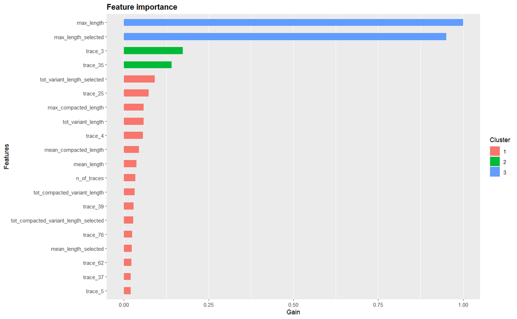

```r
# estimation of the feature importance
importance_matrix <- xgb.importance(colnames(training_dt[, !c("time_window_id","is_attack")]),
                                    model = xgboostModel)
feat_importance_plot = xgb.ggplot.importance(importance_matrix,
                                            measure = "Gain",
                                            rel_to_first = TRUE,
                                            top_n = 20)
feat_importance_plot + ylab("Gain")
```

```r
importance_matrix
```

| Feature | Gain | Cover | Frequency | Importance |
| --- | --- | --- | --- | --- |
| max_length | 3.132849e-01 | 1.340239e-01 | 7.139946e-02 | 3.132849e-01 |
| max_length_selected | 2.978727e-01 | 8.605751e-02 | 4.259511e-02 | 2.978727e-01 |
| trace_3 | 5.437413e-02 | 5.172251e-02 | 3.831522e-02 | 5.437413e-02 |
| trace_35 | 4.419393e-02 | 2.897577e-02 | 2.581522e-02 | 4.419393e-02 |
| tot_variant_length_selected | 2.854016e-02 | 3.461864e-02 | 4.660326e-02 | 2.854016e-02 |
| trace_25 | 2.301405e-02 | 2.810870e-02 | 1.949728e-02 | 2.301405e-02 |
| max_compacted_length | 1.842548e-02 | 3.704477e-03 | 3.532609e-03 | 1.842548e-02 |
| tot_variant_length | 1.838045e-02 | 2.806060e-02 | 2.866848e-02 | 1.838045e-02 |
| trace_4 | 1.769650e-02 | 9.709610e-03 | 7.133152e-03 | 1.769650e-02 |
| mean_compacted_length | 1.414172e-02 | 5.053264e-02 | 5.726902e-02 | 1.414172e-02 |

[output cut: 63 more lines]

```r
# building model
glmnetModel <- construct_glm_from_traces(training_dt, test_dt,
                                         params_glm = params_glm)
```

```
[1]  88.08   0.17 200.78
```

```r
# test score:
preds <- glmnetModel$te_preds
print(colAUC(preds, test_dt[, is_attack]))
```

```
                      s1
FALSE vs. TRUE 0.7710066
```

```r
# confusion matrix
table(preds > 0.5, test_dt[, is_attack] > 0)
```

```
        FALSE TRUE
  FALSE  3632   34
  TRUE   1209  142
```

```r
# estimation of the feature importance
coefs <- coef(glmnetModel$model, s = "lambda.min")
sum(coefs != 0)
```

```
[1] 93
```

```r
mean(coefs != 0)
```

```
[1] 0.9587629
```

```r
coefs
```

```
97 x 1 sparse Matrix of class "dgCMatrix"
                                                 s1
(Intercept)                           -4.111324e+01
trace_1                               -8.414114e+00
trace_2                               -4.706968e+00
trace_3                                1.734779e+01
trace_4                                1.900574e+00
trace_5                                7.867385e+00
trace_6                                2.917822e-01
trace_7                               -2.619842e+00
trace_8                                9.613304e-01
trace_9                               -2.700838e+00
trace_10                              -1.322198e+01
trace_11                               1.006006e+01
trace_12                               4.660168e+01
trace_13                              -5.492371e+01
trace_14                               3.201387e+01
trace_15                              -1.987376e+01
trace_16                               1.080596e+01
trace_17                              -1.436991e+01
trace_18                               7.375321e+00
trace_19                              -5.953675e+01
trace_20                              -1.587039e+00
trace_21                              -9.939137e+01
trace_22                               8.468230e+01
trace_23                               3.503051e+01
trace_24                               .
trace_25                               1.859659e+02
trace_26                               6.101028e+01
trace_27                              -6.344805e+01
trace_28                              -8.673456e+01
trace_29                              -1.854029e+01
trace_30                              -4.976691e+01
trace_31                               3.133350e+00
trace_32                              -1.574970e+01
trace_33                              -6.680843e+00
trace_34                              -4.105506e+00
trace_35                              -4.703506e+00
trace_36                               2.079136e+00
trace_37                               1.341877e+00
```

[output cut: 44 more lines]

```
max_compacted_length                   .
min_length                             3.258246e-02
mean_length                           -2.471319e-02
max_length                             8.128046e-04
n_of_traces_selected                   4.205911e-01
min_compacted_length_selected         -1.143972e+00
mean_compacted_length_selected         2.343171e+00
max_compacted_length_selected         -6.733991e-01
min_length_selected                    2.065049e-01
mean_length_selected                  -3.023693e-01
max_length_selected                    7.137683e-02
tot_variant_length                    -6.386512e-04
tot_compacted_variant_length          -9.489642e-04
tot_variant_length_selected            1.405326e-02
tot_compacted_variant_length_selected -7.164391e-02
```

### Constructing training and test sets using all **variants** from the training data (without compacting)

This representation does not use compacting - we check its result to estimate gain from the use of variant compacting.

```r
# constructing the representation by all variants from the training data (without compacting)
unique_training_traces <- model_training_trace_dt[, unique(trace)]

model_training_trace_dt[, time_window_id := sapply(strsplit(time_window_id_SYSCALL_pid, "_"), first)]
training_dt <- model_training_trace_dt[, c(as.list(unique_training_traces %chin% trace),
                                           n_of_traces = .N,
                                           min_length = min(trace_length),
                                           mean_length = mean(trace_length),
                                           max_length = max(trace_length),
                                           is_attack = first(attack)),
                                       keyby = time_window_id]
setnames(training_dt,
         1:(length(unique_training_traces)+1),
         c("time_window_id", paste0("trace_", 1:length(unique_training_traces))))

test_trace_dt[, time_window_id := sapply(strsplit(time_window_id_SYSCALL_pid, "_"), first)]
test_dt <- test_trace_dt[, c(as.list(unique_training_traces %chin% trace),
                             n_of_traces = .N,
                             min_length = min(trace_length),
                             mean_length = mean(trace_length),
                             max_length = max(trace_length),
                             is_attack = first(attack)),
                         keyby = time_window_id]

setnames(test_dt,
         1:(length(unique_training_traces)+1),
         c("time_window_id", paste0("trace_", 1:length(unique_training_traces))))
```

### Evaluation of the XGBoost model trained on the representation by all **variants** from the training data (without compacting)

```r
# building model an XGBoost model for the representation by all variants from the training data (without compacting)
xgboostModel <- construct_xgb_from_traces(training_dt, test_dt,
                                          n_trees = n_trees,
                                          params_xgb = params_xgb)
```

```
[1] 775.45   0.70 195.70
```

```r
# test score:
preds <- predict(xgboostModel, as.matrix(test_dt[, !c("time_window_id","is_attack")]))
print(colAUC(preds, test_dt[, is_attack]))
```

```
                    [,1]
FALSE vs. TRUE 0.9096425
```

```r
# confusion matrix
table(preds > training_dt[, mean(is_attack)], test_dt[, is_attack] > 0)
```

```
        FALSE TRUE
  FALSE  3902   31
  TRUE    939  145
```

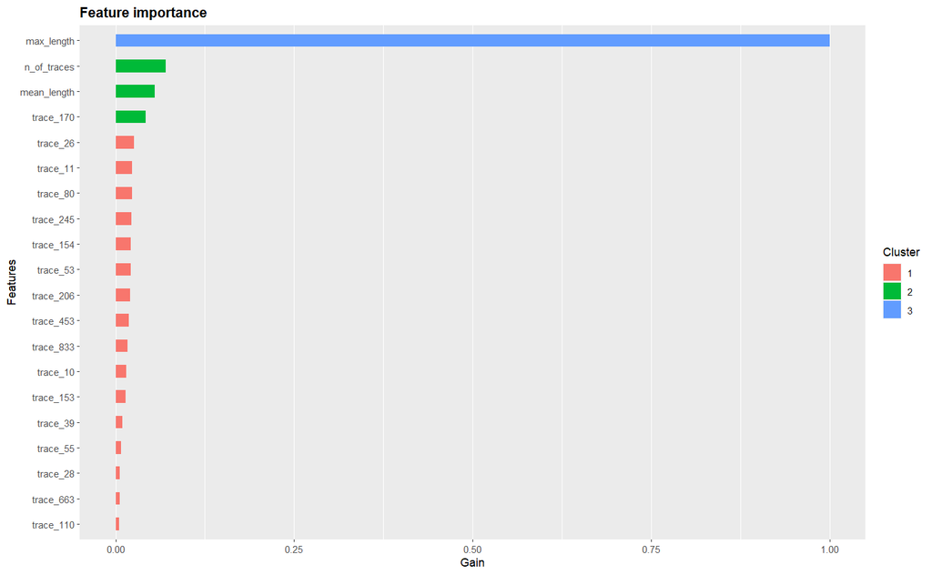

```r
# estimation of the feature importance
importance_matrix <- xgb.importance(colnames(training_dt[, !c("time_window_id","is_attack")]),
                                    model = xgboostModel)
feat_importance_plot = xgb.ggplot.importance(importance_matrix,
                                            measure = "Gain",
                                            rel_to_first = TRUE,
                                            top_n = 20)
feat_importance_plot + ylab("Gain")
```

```r
importance_matrix
```

| Feature | Gain | Cover | Frequency | Importance |
| --- | --- | --- | --- | --- |
| max_length | 6.717993e-01 | 2.233774e-01 | 1.589246e-01 | 6.717993e-01 |
| n_of_traces | 4.729603e-02 | 8.519111e-02 | 1.027735e-01 | 4.729603e-02 |
| mean_length | 3.668964e-02 | 1.770332e-01 | 2.042709e-01 | 3.668964e-02 |
| trace_170 | 2.801318e-02 | 1.911253e-02 | 1.718564e-02 | 2.801318e-02 |
| trace_26 | 1.711688e-02 | 1.118856e-02 | 1.897226e-02 | 1.711688e-02 |
| trace_11 | 1.574197e-02 | 1.773313e-02 | 1.412285e-02 | 1.574197e-02 |
| trace_80 | 1.530036e-02 | 1.128443e-02 | 1.327208e-02 | 1.530036e-02 |
| trace_245 | 1.502542e-02 | 3.541570e-03 | 5.019568e-03 | 1.502542e-02 |
| trace_154 | 1.447256e-02 | 2.639036e-02 | 2.152459e-02 | 1.447256e-02 |
| trace_53 | 1.441508e-02 | 1.218529e-02 | 7.656968e-03 | 1.441508e-02 |

[output cut: 80 more lines]

```r
# building GLMnet model
glmnetModel <- construct_glm_from_traces(training_dt, test_dt,
                                         params_glm = params_glm)
```

```
[1] 157.44   1.12 344.97
```

```r
# test score:
preds <- glmnetModel$te_preds
print(colAUC(preds, test_dt[, is_attack]))
```

```
                      s1
FALSE vs. TRUE 0.9061262
```

```r
# confusion matrix
table(preds > 0.5, test_dt[, is_attack] > 0)
```

```
        FALSE TRUE
  FALSE  4189   47
  TRUE    652  129
```

```r
# estimation of the feature importance
coefs <- coef(glmnetModel$model, s = "lambda.min")
sum(coefs != 0)
```

```
[1] 103
```

```r
mean(coefs != 0)
```

```
[1] 0.01785095
```

```r
save(training_dt, test_dt, glmnetModel, xgboostModel, params_glm, params_xgb,
     file = "data_and_models_xgb_glm_all_variants_no_compacting.RData")
```